[Return to Data Page](https://social-lorax.github.io/guides/i2.html)

[figure not shown]

```python
import numpy as np
from numpy import random
import pandas as pd

from scipy import stats
from scipy.stats import norm #normal
from scipy.stats import genextreme as gev #generalized extreme value
from scipy.stats import pareto #pareto

import matplotlib.pyplot as plt
import seaborn as sns

import warnings
warnings.filterwarnings('ignore')
```

# Probabilities

### Binary

**Random Sample**

```python
np.random.seed(1990)

pass_fail = stats.bernoulli.rvs(p = 0.7, size = 100)

pass_fail
```

```
array([0, 1, 1, 0, 1, 0, 0, 1, 0, 1, 1, 1, 1, 1, 1, 1, 1, 1, 0, 1, 0, 1,
       0, 0, 1, 0, 1, 0, 0, 1, 1, 1, 1, 1, 0, 0, 1, 0, 1, 1, 1, 1, 0, 1,
       1, 1, 0, 0, 1, 1, 1, 0, 0, 0, 1, 0, 0, 1, 1, 0, 1, 1, 1, 0, 1, 1,
       1, 1, 1, 1, 0, 1, 1, 1, 1, 1, 0, 1, 1, 1, 0, 1, 0, 1, 1, 1, 1, 0,
       1, 1, 1, 1, 0, 1, 1, 1, 0, 0, 1, 0])
```

**Probability of Success**

Expected = p

```python
round(sum(pass_fail) / len(pass_fail), 2)
```

```
0.66
```

**Probabiliy of Failure**

Expected = q = 1-p

```python
round(1 - (sum(pass_fail) / len(pass_fail)), 2)
```

```
0.34
```

**Distribution** (Bernoulli)

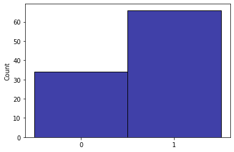

```python
pass_fail = np.array(pass_fail, dtype=str)

sns.histplot(pass_fail,
             color = 'darkblue')
plt.show()
```

### Discrete

**Random Sample**

```python
grade = np.random.choice(np.array(['A','B','C','F']), 100, p=[0.15,0.55,0.2,0.1])

grade
```

```
array(['B', 'B', 'F', 'A', 'C', 'B', 'A', 'B', 'C', 'C', 'B', 'C', 'A',
       'B', 'C', 'A', 'B', 'C', 'F', 'B', 'B', 'B', 'B', 'A', 'A', 'C',
       'C', 'C', 'B', 'B', 'A', 'B', 'A', 'F', 'B', 'B', 'B', 'B', 'B',
       'C', 'B', 'C', 'B', 'B', 'A', 'C', 'F', 'F', 'F', 'B', 'B', 'B',
       'A', 'B', 'F', 'F', 'B', 'C', 'C', 'B', 'B', 'B', 'B', 'B', 'B',
       'B', 'B', 'B', 'C', 'A', 'B', 'B', 'C', 'A', 'C', 'C', 'C', 'A',
       'B', 'B', 'B', 'F', 'A', 'C', 'F', 'B', 'B', 'B', 'B', 'B', 'C',
       'B', 'C', 'F', 'B', 'B', 'A', 'F', 'B', 'A'], dtype='<U1')
```

**Probabilities**

```python
P = {}

P["A"] = sum(grade == "A") / len(grade)
P["B"] = sum(grade == "B") / len(grade)
P["C"] = sum(grade == "C") / len(grade)
P["F"] = sum(grade == "F") / len(grade)

P
```

```
{'A': 0.16, 'B': 0.5, 'C': 0.22, 'F': 0.12}
```

**Distribution**

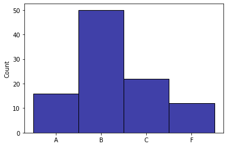

```python
grade.sort()

sns.histplot(grade,
             color = 'darkblue')
plt.show()
```

### Continuous

**Random Sample**

```python
score = np.random.normal(loc=60, scale=15, size=100)
score
```

```
array([73.83434354, 48.82310316, 77.80875324, 68.49610181, 42.32466591,
       42.36472864, 68.30201384, 55.83792431, 53.90390954, 50.96003887,
       33.3232064 , 93.74701901, 52.89054546, 49.15079921, 91.92645453,
       69.22408903, 52.70656698, 66.05942484, 58.33823835, 57.80258545,
       42.21565661, 24.13253356, 55.45735301, 76.25748409, 47.9554679 ,
       70.22832055, 94.70223591, 50.56305324, 64.59123792, 51.8993318 ,
       54.86515129, 34.72806974, 34.70640938, 29.9911896 , 75.63154502,
       59.02368411, 70.61923108, 70.9957277 , 83.62138634, 66.33992135,
       65.72616387, 54.23600947, 31.92323399, 46.35749586, 49.76830337,
       63.45562438, 56.14627691, 29.1245887 , 53.86274182, 48.70329329,
       52.67259724, 70.31590078, 52.17678861, 43.6257923 , 53.04733683,
       50.70475322, 63.67257344, 36.479866  , 53.89214535, 75.04891256,
       74.52710831, 28.12273373, 39.63674109, 60.13062326, 62.62204221,
       61.6671338 , 82.48366424, 63.59958188, 71.11383656, 58.58898051,
       34.43910375, 60.93319531, 56.241717  , 72.01832708, 34.73412604,
       57.60766964, 70.81455136, 67.79661229, 63.15229228, 74.51063676,
       64.32445602, 60.95774259, 68.28920362, 53.14734741, 54.96950597,
       80.18114508, 60.07689127, 44.22036168, 78.14400498, 45.83571224,
       47.5397776 , 48.96426129, 29.83519841, 49.6158291 , 44.78009263,
       45.69483567, 65.82288323, 59.7145169 , 57.69623983, 45.12951754])
```

**Probabilities**

The probability of a specific outcome are extremely low because there are an infinite number of possible outcomes

```python
sum(score == 80.0) / len(score)
```

```
0.0
```

Instead, look at higher, lower, or a range

```python
sum((score > 75) & (score < 85)) / len(score)
```

```
0.08
```

**Distribution**

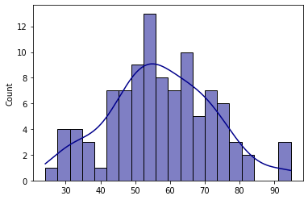

```python
sns.histplot(score,
             kde = True,
             bins = 20,
             color = 'darkblue')
plt.show()
```

[figure not shown]

# Probability Distributions

### Binomial Distribution

*A single binary event is a Bernoulli distribution, a collection of Bernoulli events is a binomial distribution.*

- The experiment consists of a fixed number of trials (n)
- Each trial has only two possible outcomes: success and failure
- The probability of success (p) and the probability of failure (q) are constant throughout the experiment
- Each trial is independent of every other trial

If true, then for n trials and r successes:

- $P[r,n]=\frac{n!}{(n-r)!r!}*p^{r}*q^{n-r}$
- $\mu = n*p$
- $\sigma = \sqrt{n*p*q}$

```python
#Eg. filliping a coin 10 times, 10000 times
trials = []

for i in range(0, 10000):
    sample = stats.bernoulli.rvs(p = 0.5, size = 10)
    trials.append(sum(sample))

print(trials[0:100])
```

```
[4, 4, 4, 3, 4, 4, 5, 5, 4, 2, 6, 4, 7, 5, 5, 5, 2, 5, 4, 5, 6, 7, 5, 4, 2, 6, 5, 5, 5, 7, 4, 7, 5, 4, 3, 6, 6, 3, 7, 5, 7, 5, 5, 4, 7, 3, 5, 5, 7, 7, 9, 5, 6, 7, 5, 4, 4, 5, 2, 4, 6, 6, 6, 4, 6, 5, 5, 6, 6, 5, 6, 5, 8, 2, 8, 5, 3, 5, 5, 6, 2, 5, 3, 5, 7, 3, 4, 3, 5, 5, 4, 4, 7, 2, 5, 6, 4, 5, 5, 6]
```

```python
#Expected = n * p = 10 * 0.5 = 5
np.mean(trials)
```

```
4.9887
```

```python
#Expected = sqrt(n * p * (1 - p)) = sqrt(10 * 0.5 * (1 - 0.5)) = 1.58
np.std(trials)
```

```
1.5829631423378119
```

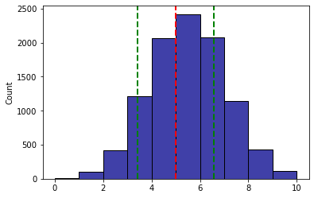

```python
sns.histplot(trials,
             color = 'darkblue',
             bins = 10)

plt.axvline(np.mean(trials), color = 'r', ls = '--', lw = 2.0)
plt.axvline(np.mean(trials) - np.std(trials), color = 'g', ls = '--', lw = 2.0)
plt.axvline(np.mean(trials) + np.std(trials), color = 'g', ls = '--', lw = 2.0)

plt.show()
```

### Poisson Distribution

- The experiment consists of counting the number of occurrences over a period or space
- The mean has to be the same for each interval of measurement (e.g. each hour or mile)
- The number of occurrences during one interval is independent of all other intervals

If true, then x given λ events in the past:

- $P[x]=\frac{\lambda^{x}*e^{-\lambda}}{x!}$
- $\mu=\lambda$
- $\sigma=\sqrt{\lambda}$

```python
#Eg. 25 hurricanes in the past 22 years

lam = 25.0 / 22

distribution = stats.poisson.pmf(range(0, 11), mu = lam)
```

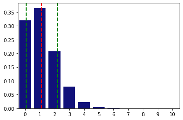

```python
sns.barplot(x = [0,1,2,3,4,5,6,7,8,9,10],
            y = distribution,
            color = 'darkblue')

plt.axvline(lam, color = 'r', ls = '--', lw = 2.0)
plt.axvline(lam - np.sqrt(lam), color = 'g', ls = '--', lw = 2.0)
plt.axvline(lam + np.sqrt(lam), color = 'g', ls = '--', lw = 2.0)

plt.show()
```

```python
#Probability of only 1
stats.poisson.pmf(1, mu = lam)
```

```
0.364754678578128
```

```python
#Probability of less than 3
sum(stats.poisson.pmf(range(0, 3), mu = lam))
```

```
0.892985772191726
```

```python
#Probability of 5 of more
1-sum(stats.poisson.pmf(range(0,5), mu = lam))
```

```
0.0062096981055900224
```

### Normal Distribution

Continuous variables

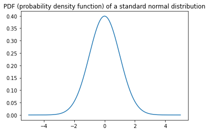

```python
x = np.array(range(-500,501)) * 0.01

plt.plot(x, stats.norm.pdf(x, 0, 1))
plt.title('PDF (probability density function) of a standard normal distribution')
plt.show()
```

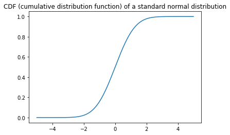

```python
plt.plot(x,stats.norm.cdf(x, 0, 1))
plt.title('CDF (cumulative distribution function) of a standard normal distribution')
plt.show()
```

**Impact of σ**

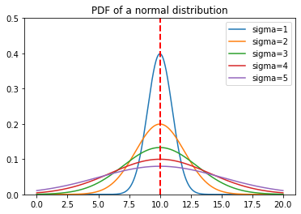

```python
x = np.array(range(0, 2000)) * 0.01
mu = 10

plt.title('PDF of a normal distribution')
for sigma in range(1,6):
    plt.plot(x, stats.norm.pdf(x, mu, sigma),label='sigma={0}'.format(sigma))

plt.legend()
plt.axvline(mu, color = 'r', ls = '--', lw = 2.0)
plt.ylim([0, 0.5])

plt.show()
```

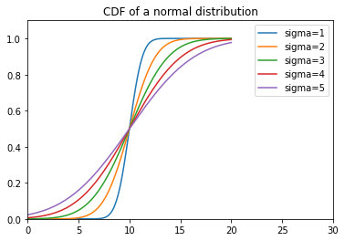

```python
plt.title('CDF of a normal distribution')
for sigma in range(1,6):
    plt.plot(x,stats.norm.cdf(x, mu, sigma), label = 'sigma={0}'.format(sigma))

plt.legend()
plt.ylim([0, 1.1])
plt.xlim([0, 30])

plt.show()
```

**Percentiles**

$Z = (x-\mu)/\sigma$

[figure not shown]

**Example**

```python
sample = np.random.normal(loc=60, scale=15, size=1000)
```

```python
sample.mean()
```

```
59.525845485081184
```

```python
sample.std()
```

```
14.440067002464144
```

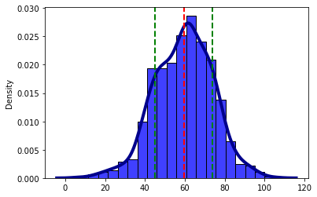

```python
sns.histplot(sample,
             bins = 20,
             color = 'blue',
             stat='density')

sns.kdeplot(sample,
            color = 'darkblue',
            linewidth = 4)

plt.axvline(sample.mean(), color = 'r', ls = '--', lw = 2.0)
plt.axvline(sample.mean() - sample.std(), color = 'g', ls = '--', lw = 2.0)
plt.axvline(sample.mean() + sample.std(), color = 'g', ls = '--', lw = 2.0)

plt.show()
```

```python
# Probability > 80
1 - norm.cdf(80, loc = sample.mean(), scale = sample.std())
```

```
0.07811419225477834
```

```python
# Probability < 80
norm.cdf(80, loc = sample.mean(), scale = sample.std())
```

```
0.9218858077452217
```

```python
# Probability < 40
norm.cdf(40, loc = sample.mean(), scale = sample.std())
```

```
0.08815581709622194
```

```python
# Probability > 40
1 - norm.cdf(40, loc = sample.mean(), scale = sample.std())
```

```
0.911844182903778
```

```python
# Probability 40 < x < 80
norm.cdf(80, loc = sample.mean(), scale = sample.std()) - norm.cdf(40, loc = sample.mean(), scale = sample.std())
```

```
0.8337299906489997
```

### Fitting a Distribution

[figure not shown]

```python
def distribution_analysis(x, log_scale = False, fit_distribution = 'None', bins = 50, vis_means = True):
    #x - array of observations
    #log_scale - analyze distribution of log(x) if True
    #fit_distribution - fit the distribution ('normal', 'gev' or 'pareto') or do nothing if 'None'
    #bins - how many bins to use for binning the data
    #vis_means - show mean and std lines if True

    if log_scale:
        x1 = np.log10(x) #convert data to decimal logarithms
        xlabel = 'log(values)' #reflect in x labels
    else:
        x1 = x #leave original scale
        xlabel = 'values'

    mu = x1.mean() #compute the mean
    if log_scale: #if logscale, output log mean, its original scale, and original scale mean
        print('Log mean = {:.2f}({:.2f}), mean = {:.2f}'.format(mu, 10**mu, x.mean()))
    else:
        print('Mean = {:.2f}'.format(mu)) #otherwise print mean

    sigma = x1.std() #compute and output standard deviation
    print('Standard deviation = {:.2f}'.format(sigma))

    #visualize histogram and the interpolated line using seaborn
    sns.histplot(x1, bins = bins, color = 'darkblue', stat = 'density')

    sns.kdeplot(x1, color = 'darkblue', linewidth = 4)

    #show vertical lines for mean and std if vis_means = True
    if vis_means:
        plt.axvline(mu, color = 'r', ls = '--', lw=2.0)
        plt.axvline(mu-sigma, color = 'g', ls = '--', lw = 2.0)
        plt.axvline(mu+sigma, color = 'g', ls = '--', lw = 2.0)

    ylim = plt.gca().get_ylim() #keep the y-range of original distribution density values
    #(to make sure the fitted distribution would not affect it)

    h = np.arange(mu - 3 * sigma, mu + 3 * sigma, sigma / 100) #3-sigma visualization range for the fitted distribution
    pars = None #fitted distribution parameters

    #fit and visualize the theoretic distribution
    if fit_distribution == 'normal':
        pars = norm.fit(x1)
        plt.plot(h,norm.pdf(h,*pars),'r')
    elif fit_distribution == 'gev':
        pars = gev.fit(x1)
        plt.plot(h,gev.pdf(h,*pars),'r')
    elif fit_distribution == 'pareto':
        pars = pareto.fit(x1)
        plt.plot(h,pareto.pdf(h,*pars),'r')

    plt.xlabel(xlabel) #add x label
    plt.ylim(ylim) #restore the y-range of original distribution density values
    plt.show()
```

```
Mean = 59.53
Standard deviation = 14.44
```

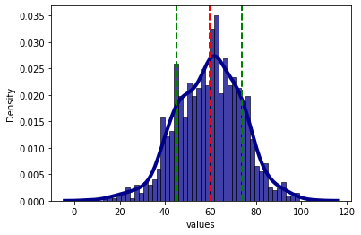

```python
distribution_analysis(sample)
```

```
Mean = 59.53
Standard deviation = 14.44
```

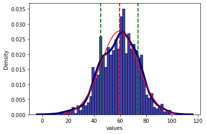

```python
distribution_analysis(sample, fit_distribution = "normal")
```

```
Mean = 59.53
Standard deviation = 14.44
```

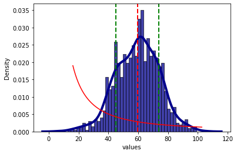

```python
distribution_analysis(sample, fit_distribution = "pareto")
```

[figure not shown]

# Inferential Statistics

```python
from  gapminder import gapminder

asia_07 = gapminder[(gapminder["continent"] == "Asia") & (gapminder["year"] == 2007)]["lifeExp"].sort_values()
africa_07 = gapminder[(gapminder["continent"] == "Africa") & (gapminder["year"] == 2007)]["lifeExp"].sort_values()
```

### Normality test

$H_0$ = the sample is normally distributed (p >= 0.05)

$H_1$ = the sample is not normally distributed (p < 0.05)

```python
def is_normal(x, sig=0.05):
    #check is the distribution is normal using one-sample KS test and sample mean-std
    test_result = stats.kstest(x,'norm', args=(x.mean(),x. std()))

    if test_result[1] < sig:
        print("Reject the null (p = " + str(round(test_result[1], 3)) + "), can't consider normal")
    else:
        print("Fail to reject the null (p = " + str(round(test_result[1], 3)) + "), safe to assume normal")
```

```python
is_normal(asia_07)
```

```
Fail to reject the null (p = 0.324), safe to assume normal
```

```python
is_normal(africa_07)
```

```
Fail to reject the null (p = 0.691), safe to assume normal
```

### T-test

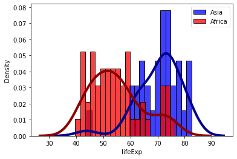

```python
sns.histplot(asia_07,
             bins = 20,
             color = 'blue',
             stat='density',
             label = "Asia")

sns.kdeplot(asia_07,
            color = 'darkblue',
            linewidth = 4)

sns.histplot(africa_07,
             bins = 20,
             color = 'red',
             stat='density',
             label = "Africa")

sns.kdeplot(africa_07,
            color = 'darkred',
            linewidth = 4)
plt.legend()
plt.show()
```

```python
stats.ttest_ind(asia_07, africa_07)
```

```
Ttest_indResult(statistic=7.9273954920841065, pvalue=9.074251950172207e-12)
```

### Kolmogorov–Smirnov test

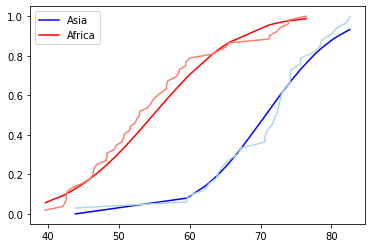

```python
from statsmodels.distributions.empirical_distribution import ECDF

plt.plot(asia_07,
         stats.norm.cdf(asia_07, asia_07.mean(), asia_07.std()),
         color = 'blue',
         label = "Asia")

asia_ecdf = ECDF(asia_07)
plt.plot(asia_ecdf.x, asia_ecdf.y, color = "lightblue")

plt.plot(africa_07,
         stats.norm.cdf(africa_07, africa_07.mean(), africa_07.std()),
         color = 'red',
         label = "Africa")

africa_ecdf = ECDF(africa_07)
plt.plot(africa_ecdf.x, africa_ecdf.y, color = "salmon")

plt.legend()
plt.show()
```

```python
stats.ks_2samp(asia_07, africa_07)
```

```
KstestResult(statistic=0.7389277389277389, pvalue=2.5241475576365247e-11)
```